# CanLEAD

## Summary Description

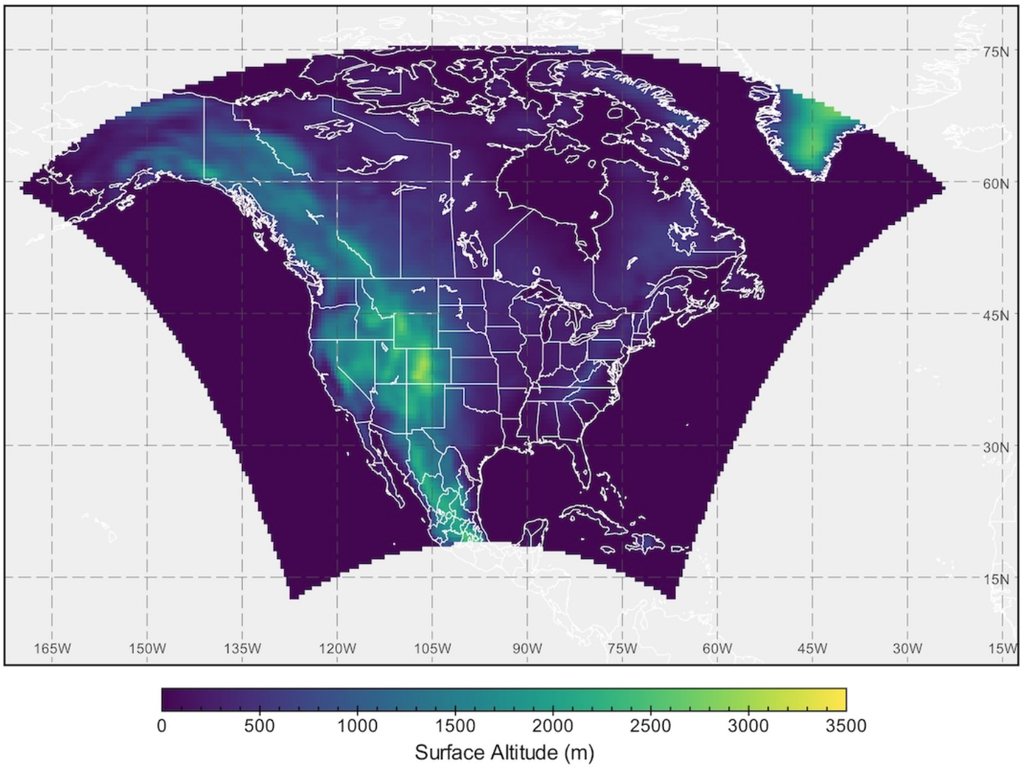

CanLEADv1 domain for CanRCM4. See Cannon *et al.* (2022) for the CanESM2 domain.

## Dataset Characteristics

- **Current version:** v1
- **Available variables:** temperature, precipitation, wind, relative humidity, surface pressure, longwave and shortwave radiation (see variables section below)
- **Temporal coverage**: 1950-2100
- **Temporal resolution:** daily
- **Spatial coverage:** North America
- **Spatial resolution:** 0.5°
- **Data type:** Bias-adjusted climate projections
- **Data format:** netCDF
- **Web references:**  
  [Government of Canada’s Open data portal](https://open.canada.ca/data/en/dataset/a97edbc1-7fda-4ebc-b135-691505d9a595)
- **Reference:**  
  Cannon *et al.* (2022)
- **Contact:** Alex J. Cannon Climate Research Division, Victoria, BC

### When to use CanLEADv1

- When you need **large ensembles of climate projections**
- When you want to quantify **uncertainty arising from natural variability** rather than model differences
- When you want to assess **risk or robust statistics of extreme events** using many realizations of the same model (e.g., return periods, tail risks)
- When you need **probabilistic information** (e.g., likelihood of exceeding thresholds)
- When you want to separate **forced climate change signals from internal variability**
- When you want to evaluate **year-to-year and decade-to-decade variability** in future climate due to the chaotic nature of the climate system itself.
- When you want to complement **multi-model ensembles (e.g., CMIP6)** with **large initial-condition ensembles**

## Strengths and Limitations

### Key Strengths of CanLEAD

[output not shown]

### Key Limitations of CanLEAD

| Limitation | Description |
| --- | --- |
| **Lower resolution** | The spatial resolution is lower compared to other bias-adjusted datasets. |
| **Only two models** | Only includes one RCM and one GCM, where the RCM is driven by the GCM. Model uncertainty is not sampled with this dataset. |
| **Only one scenario** | Only emission scenario RCP8.5 is available. Scenario uncertainty is not sampled with this dataset. |
| **CMIP5 era** | The dataset is based on CMIP5 data, which is not the most recent data available and uses different experiments than CMIP6. |
| **Lack of reference datasets valuation** | The reference datasets S14FD and EWEMBI have not been evaluated against other observational or reanalysis datasets for Canada which are documented in this guide. |

## Expert Guidance

**None(click to expand)**

Large ensembles are created by running the same experiment with the same model multiple times while using slightly different initial conditions. Due to the chaotic nature of the climate system, these small initial differences quickly grow into differing climatic conditions and weather sequences in each simulation. These ensembles are useful to identify signal from noise and how much uncertainty comes purely from internal variability.

CanLEADv1 consists of bias-adjusted versions the Canadian Earth System Model Large Ensembles (CanESM2 LE) produced with the Canadian Earth System Model Version 2 (CanESM2; Arora *et al.* (2011)) and the Canadian Regional Climate Model Large Ensemble (CanRCM4 LE) generated using the Canadian Regional Climate Model Version 4 (CanRCM4; Scinocca *et al.* (2016)). All 50 members for both CanESM2 and CanRCM4 were processed to downscale 8 variables using the multivariate bias-adjustment method MBCn (Cannon (2018)) and two reference datasets (S14FD and EWEMBI). The experiments include historical (1950-2005) and RCP8.5 (2006–2100) for both models and historicalNAT (1950–2020) for CanESM2-LE only. The NAT (natural) forcing represents a world without human influence on the climate system. With 2 scenarios and 2 reference datasets CanESM LE simulations amount to 2 x 2 x 50 = 200 (22,200 simulated years) while for CanRCM4 LE simulations were adjusted using 2 references resulting in 2 x 50 = 100 available simulations (15,100 simulated years).

CanLEADv1 explicitly samples observational uncertainty by using two observationally constrained reference datasets. It captures internal climate variability via a 50-member initial-condition ensemble from a single climate model. In contrast, other uncertainty sources are excluded: model uncertainty is not addressed because only one modeling system is used, and emissions scenario uncertainty is omitted because projections are based solely on RCP8.5.

Furthermore, with its high climate sensitivity climate model and its high emission scenario, the CanLEAD ensemble warms much faster than other datasets. To circumvent this issue, it is possible to analyse the dataset using the global warming level approach rather than future time horizons. Information on how to convert future time periods and GW level with this dataset is provided in Environment and Climate Change Canada (ECCC) (2021) (Section 5.4).

The resolution might not be high enough for all applications. For example, hydrological modelling on small basins is not recommended by the dataset producers.

Singh *et al.* (2022) showed that CanLEADv1 simulations bias-adjusted with the S14FD reanalysis perform slightly better over Canada than the CanLEAD simulations bias-adjusted using the EWEMBI reanalysis. They also provide a thorough analysis of the product for the different seasons. Unfortunately, S14FD and EWEMBI have not been evaluated against other observational or reanalysis datasets over Canada that are documented in this guide. See Cannon *et al.* (2022) for the references for these datasets.

The CanESM2 LE also includes an ensemble of simulations that does not include anthropogenic emissions. A comparison of the simulations using natural and anthropogenic emissions allows a direct comparison between scenarios with and without anthropogenic forcing.

The dataset was used to develop projections of future fire weather over Canada (Van Vliet *et al.* (2024)) and a climate change assessment relevant to the National Building Code of Canada and the Canadian Highway Bridge Design Code (Cannon *et al.* (2020)).

The following table provides an overview of the differnet versions of ensembles provided with CanLEADv1:

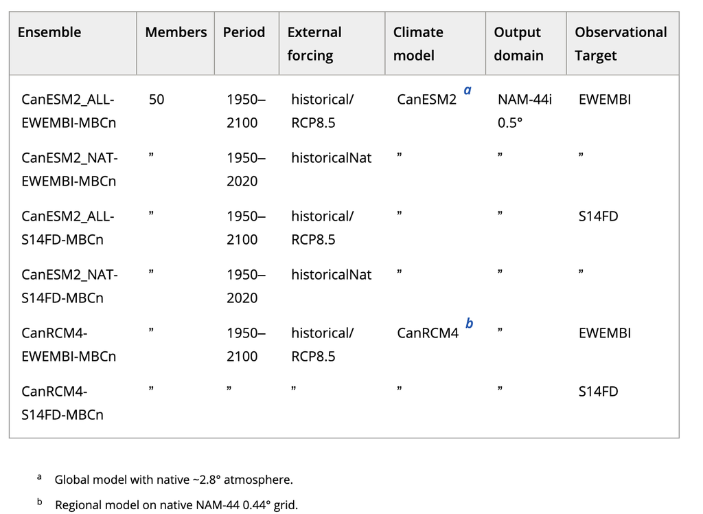

Overview of the different ensembles of CanLEADv1 (source: Table 2 from Cannon *et al.* (2022))

## Variables available in CanLead

*For details click on variable group to uncollapse*

**NoneTemperature**

- Daily maximum near-surface (2 m) air temperature (tasmax) [K]
- Daily minimum near-surface (2 m) air temperature (tasmin) [K]

Minimum and maximum temperature are derived from bias-adjustment of the mean daily temperature (tasmin + tasmax)/2 and the daily temperature range (dtr = tasmax − tasmin).

**NonePrecipitation**

- Daily mean precipitation rate (pr) [kg m−2 s−1]

**NoneWind**

- Daily mean near-surface (10 metre) wind speed (sfcWind) [m s−1]

**NoneRelative humidity**

- Daily mean near-surface relative humidity (hurs) [%]

Relative humidity (with respect to liquid water) is derived from specific humidity (huss), temperature (tas) and surface air pressure (ps) (Bolton, 1980). A logit transformation was applied to relative humidity (hurs) before the adjustment.

**NoneRadiation**

- Daily mean surface downwelling shortwave radiation (rsds) [W m−2]
- Daily mean surface downwelling longwave radiation (rlds) [W m−2]

**NonePressure**

- Daily mean surface air pressure (ps) [Pa]

## Data Access

The CanLEADv1 dataset can be downloaded from the [Government of Canada’s Open Data Portal](https://open.canada.ca/data/en/dataset/a97edbc1-7fda-4ebc-b135-691505d9a595).

## References

**(click to expand)**

Arora, V. K., Scinocca, J. F., Boer, G. J., … Merryfield, W. J. (2011). Carbon emission limits required to satisfy future representative concentration pathways of greenhouse gases. *Geophysical Research Letters*, **38**(5). doi:https://doi.org/10.1029/2010GL046270

Cannon, A. J. (2018). [Multivariate quantile mapping bias correction: An n-dimensional probability density function transform for climate model simulations of multiple variables](https://doi.org/10.1007/s00382-017-3580-6). *Climate Dynamics*, **50**(1), 31–49.

Cannon, A. J., Alford, H., Shrestha, R. R., Kirchmeier-Young, M. C., & Najafi, M. R. (2022). [Canadian large ensembles adjusted dataset version 1 (CanLEADv1): Multivariate bias-corrected climate model outputs for terrestrial modelling and attribution studies in north america](https://doi.org/10.1002/gdj3.142). *Geoscience Data Journal*, **9**(2), 288–303.

Cannon, A. J., Jeong, D. I., Zhang, X., & Zwiers, F. W. (2020). *Climate-resilient buildings and core public infrastructure: An assessment of the impact of climate change on climatic design data in canada*, Government of Canada, Ottawa, ON. Retrieved from https://publications.gc.ca/site/eng/9.893021/publication.html

Environment and Climate Change Canada (ECCC). (2021). *Climate-resilient buildings and core public infrastructure report: Plain language summary*, Government of Canada, Ottawa, ON. Retrieved from https://publications.gc.ca/pub?id=9.893021&sl=0

Maher, N., Milinski, S., & Ludwig, R. (2021). [Large ensemble climate model simulations: Introduction, overview, and future prospects for utilising multiple types of large ensemble](https://doi.org/10.5194/esd-12-401-2021). *Earth System Dynamics*, **12**(2), 401–418.

Scinocca, J. F., Kharin, V. V., Jiao, Y., … Dugas, B. (2016). [Coordinated global and regional climate modeling](https://doi.org/10.1175/JCLI-D-15-0161.1). *Journal of Climate*, **29**(1), 17–35.

Singh, H., Najafi, M. R., & Cannon, A. (2022). [Evaluation and joint projection of temperature and precipitation extremes across canada based on hierarchical bayesian modelling and large ensembles of regional climate simulations](https://doi.org/10.1016/j.wace.2022.100443). *Weather and Climate Extremes*, **36**, 100443.

Van Vliet, L., Fyke, J., Nakoneczny, S., Murdock, T. Q., & Jafarpur, P. (2024). [Developing user-informed fire weather projections for canada](https://doi.org/10.1016/j.cliser.2024.100505). *Climate Services*, **35**, 100505.